# Leitura Dinâmica: Comunicação entre Fluxos de Controle

LP4A/PUCSP, ItaloSV, 2018

# 1 Introdução

Nesta versão, veremos como interromper um fluxo de controle a partir de outro.

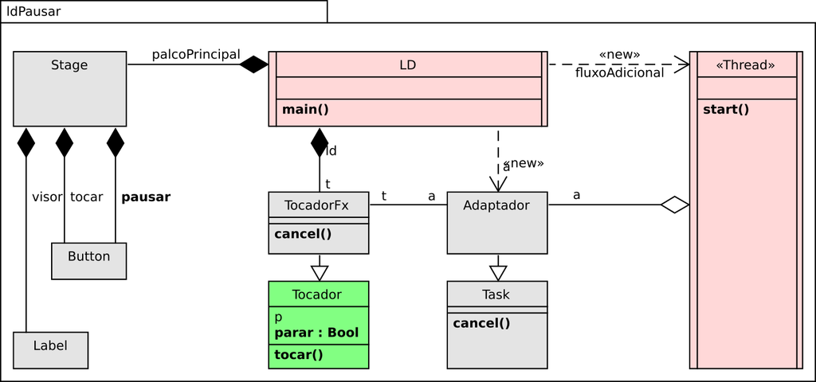

Esta versão modifica a maioria das classes desta arquitetura (exceto a `Executor`). Por meio destas alterações, o usuário poderá enviar eventos do tipo **Pausar**, cujo tratamento interromperá o fluxo de controle que toca a lista de palavras.

# 2 Classe `Adaptador`

**Tarefa**

1. No BlueJ, salve o projeto anterior **ldTocar** como **ldPausar**
2. Verifique a classe `Adaptador`:

Listagem 1: Interface exigida pelo Adaptador

```java
// Adaptador (v0.6)::
import javafx.concurrent.Task;
```

**Tarefa**

Verifique o método de construção de adaptadores:

Listagem 2: Método construtor de objetos da classe Adaptador

```java
    // Adaptador (v0.6)::
    Adaptador(TocadorFx tocador) {
        t = tocador;
    }
    TocadorFx t;
```

**Tarefa**

Verifique o método do fluxo de controle

Listagem 3: Método que redireciona o fluxo de controle para a lógica que toca as palavras

```java
    // Adaptador (v0.6)::
    @Override
    protected Void call() throws Exception {
        t.tocar(this);
        return null; // <-- Porquê?
    }
```

## 2.1 Exercícios

1. Desenhe um DCL com as classes Adaptador e TocadorFx.
2. Qual “natureza” da associação entre elas?
3. Desenhe um **DSM** com as classes `Adaptador` e `TocadorFx`.

# 3 Classe `Executor`

Esta classe apenas extende a classe `Thread`, o que permitirá observá-la no ambiente BlueJ,

**Tarefa**

Verifique o construtor de objetos da classe `Executor`

```java
// Executor (v0.6)::
public class Executor extends Thread {
    // Para explicitar a classe "Thread" no BlueJ
    Executor(Adaptador a) {
        super(a);
    }

}
```

## 3.1 Exercícios

1. Desenhe um **DSM** com as classes `Executor` e `Adaptador`.
2. Refine o modelo, incorporando o botão **Pausar**.

# 4 Classe `LD`

**Tarefa**

**Altere** a classe `LD`:

Listagem 5: Método que constrói o painel da `LD`

```java
    // LD (v0.6)::
    @Override
    public void start(Stage palcoPrincipal) throws Exception {
        // Tocador de palavras de texto
        t = new TocadorFx(this);
        // Definição do painel de interação
        VBox raiz = new VBox(5);
        definirTexto(raiz);
        definirVelocidade(raiz);
        definirBotaoTocar(raiz);
        definirBotaoPausar(raiz); // <-- (1)
        definirVisor(raiz);
        // Cena principal
        Scene cena = new Scene(raiz, 200, 250, Color.WHITE);
        palcoPrincipal.setScene(cena);
        palcoPrincipal.setTitle("Leitura Dinâmica, v0.6");
        palcoPrincipal.show();
    }
    TextField textoCmp;
    TextField periodoCmp;
    TocadorFx t;
```

**Tarefa**

Verifique a definição do botão **Tocar** na classe `LD`:

Listagem 6: Método que define o botão Tocar

```java
    // LD (v0.6)::
    void definirBotaoTocar(VBox raiz) {
        tocarEvt = new Button("Tocar");
        tocarEvt.setDisable(false);
        tocarEvt.setOnAction(e -> {
            tocarEvt.setDisable(true);
            pausarEvt.setDisable(false);
            // Reação a eventos "Tocar"
            Adaptador a = new Adaptador(t);
            Executor fluxoAdicional = new Executor(a);
            fluxoAdicional.start();
        });
        raiz.getChildren().add(tocarEvt);
    }
    Button tocarEvt;
```

**Tarefa**

Implemente a definição do botão **Pausar** na classe `LD`:

Listagem 7: Método que define o botão Pausar

```java
    // LD (v0.6)::
    void definirBotaoPausar(VBox raiz) {
        pausarEvt = new Button("Pausar");
        pausarEvt.setDisable(true);
        pausarEvt.setOnAction(e -> {
            tocarEvt.setDisable(false);
            pausarEvt.setDisable(true);
            // Reação a eventos "Pausar"
            t.cancel();
        });
        raiz.getChildren().add(pausarEvt);
    }
    Button pausarEvt;
```

# 5 Classe `Tocador`

**Tarefa**

**Altere** o construtor de objetos da classe `Tocador`:

Listagem 8: Método que constrói o `Tocador`

```java
    // Tocador (v0.6)::
    Tocador() {
        p = 0; // índice da palavra mostrada
        parar = false; // encerra o fluxo que toca palavras
    }

    int p;
    boolean parar;
```

**Tarefa**

**Altere** o método que toca as palavras da lista:

Listagem 9: Método que toca palavras

```java
    // Tocador (v0.6)::
    void tocar(String[] listaPal, long velocidade) {
        int n = listaPal.length;
        for (; p < n; p++) {
            if (parar) {
                // encerra o fluxo que toca palavras
                return;
            }
            mostrar(listaPal[p]);
            suspender(velocidade);
        }
    }
```